# COMP41680 - API Assignment

## 17203932 Narae Kim

```python
import urllib.request
import requests
import csv
import pandas as pd
import matplotlib
import matplotlib.pyplot as plt
%matplotlib inline
```

# Task 1: Identify one or more suitable web APIs

A stock time series API supplied by https://www.alphavantage.co/documentation/

The API requires an API key to gain more details. I received one available API key which is "XC9H3RUATIRPZVWJ." However, it is only for a temporary access so that I would like you to let me know if you cannot access the data then I will send another one. In that case, please email me to narae.kim@ucdconnect.ie.

Here, I will pick two companies up which are Microsoft named MSFT and Google named GOOG.

```python
api_key = "XC9H3RUATIRPZVWJ"
microsoft = "MSFT"
google = "GOOG"
```

# Task 2: Collect data your chosen API(s)

```python
def download_csv(file_csv, function, symbol=google, api_key=api_key):
    url = "https://www.alphavantage.co/query?function="+function+"&symbol="+symbol+"&apikey="+api_key+"&datatype=csv"
    urllib.request.urlretrieve(url, file_csv) # request a file by the url and save it to the name of file_loc


''' # This is also possible instead of the function above.
# download CSV files by the url from the given variables
def download_csv(file_loc, function, symbol=google, api_key=api_key):
    url = "https://www.alphavantage.co/query?function="+function+"&symbol="+symbol+"&apikey="+api_key+"&datatype=csv"
    response = urllib.request.urlopen(url)
    raw_csv = response.read().decode()
    with open(file_loc, "w",newline='') as write_file: # write the file / newline ='' to prevent blank lines being written
        f = csv.writer(write_file)
        lines = raw_csv.strip().split("\r\n") # for the only meaninful data
        for line in lines:
            if line[0] =="#": # prevent it from writing the comments in the return of each API call
                continue
            else:
                line = line.split(",") # to store strings in a list for analysing later
                f.writerow(line)
    write_file.close()
'''
```

```
' # This is also possible instead of the function above.\n# download CSV files by the url from the given variables\ndef download_csv(file_loc, function, symbol=google, api_key=api_key): \n    url = "https://www.alphavantage.co/query?function="+function+"&symbol="+symbol+"&apikey="+api_key+"&datatype…
```

# Task 3: Parse the collected data, and store it in an appropriate file format

As planned, I will save 4 CSV files for Google and Microsoft stocks on the daily and monthly basis from the closest time asked.

```python
GOOG_daily_csv = "GOOG-daily.csv" # daily intervals
GOOG_monthly_csv = "GOOG-monthly.csv" # monthly intervals
GOOG_file_csv = [GOOG_daily_csv, GOOG_monthly_csv]

MSFT_daily_csv = "MSFT-daily.csv" # daily intervals
MSFT_monthly_csv = "MSFT-monthly.csv" # monthly intervals
MSFT_file_csv = [MSFT_daily_csv, MSFT_monthly_csv]

daily_fn = "TIME_SERIES_DAILY"
#weekly_fn = "TIME_SERIES_WEEKLY"
monthly_fn = "TIME_SERIES_MONTHLY"
functions = [daily_fn, monthly_fn]

# request CSV files and save the data in the files
for i in range(len(functions)):
    try:
        download_csv(GOOG_file_csv[i],functions[i], symbol=google)
        download_csv(MSFT_file_csv[i], functions[i], symbol=microsoft)
    except PermissionError :
        print("There is a file with the same name:",GOOG_file_csv,MSFT_file_csv, "\nPlease delete the file and start again.")
```

# Task 4: Load and represent the data as a Pandas Dataframe. Apply any pre-processing steps to clean and filter the data

The stock datasets are recalled by daily or monthly intervals to analyse as a pandas dataframe.

```python
GOOGdailyData = pd.read_csv("GOOG-daily.csv")
GOOGmonthlyData = pd.read_csv("GOOG-monthly.csv")

MSFTdailyData = pd.read_csv("MSFT-daily.csv")
MSFTmonthlyData = pd.read_csv("MSFT-monthly.csv")
```

```python
heading = ["timestamp","open","high","low","close","volume"] # default heading from the downloaded CSV files
GOOG_headings = ["timestamp","GOOG_open","GOOG_high","GOOG_low","GOOG_close","GOOG_volume"] # new heading to distinguish a company name
MSFT_headings = ["timestamp","MSFT_open","MSFT_high","MSFT_low","MSFT_close","MSFT_volume"]

GOOG_col=dict(zip(heading, GOOG_headings)) # dictionary between the old header and the new header
MSFT_col=dict(zip(heading, MSFT_headings))

GOOGdailyData.rename(columns=GOOG_col, inplace=True) # exchange the headers to the new one
GOOGmonthlyData.rename(columns=GOOG_col, inplace=True)
MSFTdailyData.rename(columns=MSFT_col, inplace=True)
MSFTmonthlyData.rename(columns=MSFT_col, inplace=True)

MSFTdailyData[0:4]
```

|  | timestamp | MSFT_open | MSFT_high | MSFT_low | MSFT_close | MSFT_volume |
| --- | --- | --- | --- | --- | --- | --- |
| 0 | 2018-03-23 | 89.500 | 90.46 | 87.08 | 87.18 | 43855857 |
| 1 | 2018-03-22 | 91.265 | 91.75 | 89.66 | 89.79 | 37578166 |
| 2 | 2018-03-21 | 92.930 | 94.05 | 92.21 | 92.48 | 23753263 |
| 3 | 2018-03-20 | 93.050 | 93.77 | 93.00 | 93.13 | 21787780 |

```python
MSFTmonthlyData[0:4]
```

|  | timestamp | MSFT_open | MSFT_high | MSFT_low | MSFT_close | MSFT_volume |
| --- | --- | --- | --- | --- | --- | --- |
| 0 | 2018-03-23 | 93.990 | 97.2400 | 87.08 | 87.18 | 527458461 |
| 1 | 2018-02-28 | 94.790 | 96.0700 | 83.83 | 93.77 | 690287596 |
| 2 | 2018-01-31 | 86.125 | 95.4500 | 85.50 | 95.01 | 543377322 |
| 3 | 2017-12-29 | 83.600 | 87.4999 | 80.70 | 85.54 | 447828256 |

As I am interested in the highest and lowest values within each time-frequency, I will sort out the data what I need. In this case, the datasets are named "GOOG_Daily" and "GOOG_Monthly" as well as "MSFT_Daily" and "MSFT_Monthly" in order to distinguish the given data. Also, I will sort the datasets by timestamp so that the rows will show up from the oldest ones to the latest ones for graphing.

```python
GOOG_Daily = GOOGdailyData[["timestamp", "GOOG_high", "GOOG_low"]] # filtering features
GOOG_Daily = GOOG_Daily.sort_values(by=["timestamp"])  # sort the date backward to draw a graph

GOOG_Monthly = GOOGmonthlyData[["timestamp", "GOOG_high", "GOOG_low"]]
GOOG_Monthly = GOOG_Monthly.sort_values(by=["timestamp"])  # sort the date backward to draw a graph

MSFT_Daily = MSFTdailyData[["timestamp", "MSFT_high", "MSFT_low"]]
MSFT_Daily = MSFT_Daily.sort_values(by=["timestamp"])  # sort the date backward to draw a graph

MSFT_Monthly = MSFTmonthlyData[["timestamp", "MSFT_high", "MSFT_low"]]
MSFT_Monthly = MSFT_Monthly.sort_values(by=["timestamp"])  # sort the date backward to draw a graph
```

```python
MSFT_Monthly[0:4]
```

|  | timestamp | MSFT_high | MSFT_low |
| --- | --- | --- | --- |
| 217 | 2000-02-29 | 110.0 | 88.12 |
| 216 | 2000-03-31 | 115.0 | 88.94 |
| 215 | 2000-04-28 | 96.5 | 65.00 |
| 214 | 2000-05-31 | 74.0 | 60.38 |

However, I would combine the daily datasets between Google and Microsoft as well as the monthly datasets. The purpose of doing this process is that I will focus more on each time periods for 'Task 5' but also need to compare the stock values with appropriate timestamps.

```python
DailyMerged = pd.merge(GOOG_Daily, MSFT_Daily,how='inner', on = 'timestamp') # merge the datasets of two companies to be compared
DailyMerged.to_csv('DailyMerged.csv', index=False) # recreate a merged CSV
MonthlyMerged = pd.merge(GOOG_Monthly, MSFT_Monthly,how='inner', on = 'timestamp')
MonthlyMerged.to_csv('MonthlyMerged.csv', index=False)

print("DailyMerged:\n",DailyMerged[0:3])
print("\nMonthlyMerged:\n",MonthlyMerged[0:3])
```

```
DailyMerged:
     timestamp  GOOG_high  GOOG_low  MSFT_high  MSFT_low
0  2017-10-30    1024.97   1007.50     84.325    83.105
1  2017-10-31    1024.00   1010.42     84.360    83.110
2  2017-11-01    1029.67   1016.95     83.760    82.880

MonthlyMerged:
     timestamp  GOOG_high  GOOG_low  MSFT_high  MSFT_low
0  2014-04-30     604.83    502.80      41.66     38.90
1  2014-05-30     567.84    503.30      40.97     38.51
2  2014-06-30     582.45    538.75      42.29     39.86
```

In order to set up the index-columns from the merged CSV files, I recall those files again as DailyMerged and MonthlyMerged.

```python
DailyMerged = pd.read_csv('DailyMerged.csv',index_col="timestamp")
MonthlyMerged = pd.read_csv('MonthlyMerged.csv',index_col="timestamp")
```

```python
DailyMerged[0:3]
```

| timestamp | GOOG_high | GOOG_low | MSFT_high | MSFT_low |
| --- | --- | --- | --- | --- |
| 2017-10-30 | 1024.97 | 1007.50 | 84.325 | 83.105 |
| 2017-10-31 | 1024.00 | 1010.42 | 84.360 | 83.110 |
| 2017-11-01 | 1029.67 | 1016.95 | 83.760 | 82.880 |

### Missing Data

Final Pre-Processing steps are to look for missing data to see if further pre-processing is needed.

```python
print("The numbers show how many numbers of missing data are in each CSV file.",\
     '\n\nThe simplified file of "GOOG-daily.csv":\n', GOOG_Daily.isnull().sum(),\
     '\n\nThe simplified file of "GOOG-montly.csv":\n', GOOG_Monthly.isnull().sum(),\
     '\n\nThe simplified file of "MSFT-daily.csv":\n', MSFT_Daily.isnull().sum(),\
     '\n\nThe simplified file of "MSFT-montly.csv":\n', MSFT_Monthly.isnull().sum(),\
     '\n\nThe simplified file of "DailyMerged.csv":\n', DailyMerged.isnull().sum(),\
     '\n\nThe simplified file of "MonthlyMerged.csv":\n', MonthlyMerged.isnull().sum(),\
     )
```

```
The numbers show how many numbers of missing data are in each CSV file.

The simplified file of "GOOG-daily.csv":
 timestamp    0
GOOG_high    0
GOOG_low     0
dtype: int64

The simplified file of "GOOG-montly.csv":
 timestamp    0
GOOG_high    0
GOOG_low     0
dtype: int64

The simplified file of "MSFT-daily.csv":
 timestamp    0
MSFT_high    0
MSFT_low     0
dtype: int64

The simplified file of "MSFT-montly.csv":
 timestamp    0
MSFT_high    0
MSFT_low     0
dtype: int64

The simplified file of "DailyMerged.csv":
 GOOG_high    0
GOOG_low     0
MSFT_high    0
MSFT_low     0
dtype: int64

The simplified file of "MonthlyMerged.csv":
 GOOG_high    0
GOOG_low     0
MSFT_high    0
MSFT_low     0
dtype: int64
```

### Handling Missing Values

However, if there is any null data in case, then we can follow the next steps below.This is estimating the missing values using the mean value. If we want to try it, we can intentionally change some data by deleting the values.

```python
DailyMerged["GOOG_high"][3:6]=None # to empty cells to test processes for missing values
DailyMerged["GOOG_low"][9]=None
DailyMerged["MSFT_high"][7]=None
print(DailyMerged[0:11])
```

[output not shown]

```python
daily_null_info = DailyMerged.isnull().sum()
print(dict(daily_null_info))
```

```
{'GOOG_high': 3, 'GOOG_low': 1, 'MSFT_high': 1, 'MSFT_low': 0}
```

```python
def filling_mean(dataset):
    null_info = dataset.isnull().sum()
    for k,v in null_info.items(): # k-keys; v-values of the null info.
        if v != 0: # if there are missing values
            mean_key = dataset[k].mean()
            dataset[k] = dataset[k].fillna(mean_key) # fill up the empty value to the mean value
    return print("Data Cleaning Done.\n")
```

```python
filling_mean(DailyMerged)

DailyMerged.isnull().sum()
```

```
Data Cleaning Done.
```

```
GOOG_high    0
GOOG_low     0
MSFT_high    0
MSFT_low     0
dtype: int64
```

```python
filling_mean(MonthlyMerged)
MonthlyMerged.isnull().sum()
```

```
Data Cleaning Done.
```

```
GOOG_high    0
GOOG_low     0
MSFT_high    0
MSFT_low     0
dtype: int64
```

```python
print("The information for GOOG Daily data:\n", GOOG_Daily.dtypes.value_counts(),\
      "\n\nThe information for GOOG Monthly data:\n", GOOG_Monthly.dtypes.value_counts(),\
      "\n\nThe information for MSFT Daily data:\n", MSFT_Daily.dtypes.value_counts(),\
      "\n\nThe information for MSFT Monthly data:\n", MSFT_Monthly.dtypes.value_counts(),\
      "\n\n\nThe information for DailyMerged data:\n", DailyMerged.dtypes.value_counts(),\
      "\n\nThe information for MonthlyMerged data:\n", MonthlyMerged.dtypes.value_counts(),\
     )
```

```
The information for GOOG Daily data:
 float64    2
object     1
dtype: int64

The information for GOOG Monthly data:
 float64    2
object     1
dtype: int64

The information for MSFT Daily data:
 float64    2
object     1
dtype: int64

The information for MSFT Monthly data:
 float64    2
object     1
dtype: int64


The information for DailyMerged data:
 float64    4
dtype: int64

The information for MonthlyMerged data:
 float64    4
dtype: int64
```

The results of the first four datasets are different from the last two. Because the merged datasets includes the information of two sets, the merged datasets have two more numbers of columns. Nevertheless, the information indicates no string in DailyMerged and MonthlyMerged. Therefore, the data is valid to be analysed with Pandas, Matplotlib, etc.

# Task 5:Analyse and summarise the cleaned dataset

### Descriptive Statistics

```python
print('Descriptive Statistics - "GOOG_Daily":\n' )
print(GOOG_Daily.describe())
print('\n\nDescriptive Statistics - "MSFT_Daily":\n' )
print(MSFT_Daily.describe())
print('\n\nDescriptive Statistics - "GOOG_Monthly":\n' )
print(GOOG_Monthly.describe())
print('\n\nDescriptive Statistics - "MSFT_Monthly":\n' )
print(MSFT_Monthly.describe())
print('\n\nDescriptive Statistics - "DailyMerged":\n' )
print(DailyMerged.describe())
print('\n\nDescriptive Statistics - "MonthlyMerged":\n' )
print(MonthlyMerged.describe())
```

```
Descriptive Statistics - "GOOG_Daily":

         GOOG_high     GOOG_low
count   100.000000   100.000000
mean   1087.388480  1068.095710
std      49.726046    49.128642
min    1016.100000   988.280000
25%    1043.436500  1025.097500
50%    1080.100000  1055.735000
75%    1125.037500  1103.607500
max    1186.890000  1171.980000


Descriptive Statistics - "MSFT_Daily":

        MSFT_high    MSFT_low
count  100.000000  100.000000
mean    89.148778   87.570194
std      4.460753    4.168197
min     82.590000   80.700000
25%     84.782500   83.737500
50%     88.653600   87.160000
75%     93.447500   91.635000
max     97.240000   96.040000


Descriptive Statistics - "GOOG_Monthly":

         GOOG_high     GOOG_low
count    48.000000    48.000000
mean    774.786590   703.982263
std     187.013418   169.848039
min     541.410000   487.560000
25%     594.195000   542.852500
50%     766.303750   688.607500
75%     869.337500   806.782500
max    1186.890000  1045.230000


Descriptive Statistics - "MSFT_Monthly":
```

[output cut: 21 more lines]

```
75%    1125.037500  1103.607500   93.447500   91.635000
max    1186.890000  1171.980000   97.240000   96.040000


Descriptive Statistics - "MonthlyMerged":

         GOOG_high     GOOG_low  MSFT_high   MSFT_low
count    48.000000    48.000000  48.000000  48.000000
mean    774.786590   703.982263  59.838537  54.741250
std     187.013418   169.848039  15.265839  14.189916
min     541.410000   487.560000  40.970000  38.510000
25%     594.195000   542.852500  47.875000  43.042500
50%     766.303750   688.607500  55.515000  49.925000
75%     869.337500   806.782500  66.927500  63.927500
max    1186.890000  1045.230000  97.240000  87.080000
```

Here, we could see the mean of the google stock is nearly 12 times or 13 times of the Microsoft's.

I would also point out the results of std, which shows how much the data spread around as much as high values. Therefore, the DailyMerged would behave more tightly each other than MonthlyMerged's. In other words, we might be better to predict the short term of the future data with DailyMerged with a less error gap.

### Matplotlib and Pandas Graphing

Now, we are dealing with mainly two different time periods, day and month. That information would be a matter of scale size. However, my data can hardly cover the massive data synchronised as much as the longest time term. Therefore, I would analyse those data separately. The purpose of doing that is looking for appropriate patterns or trends to predict the future data.

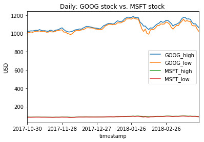

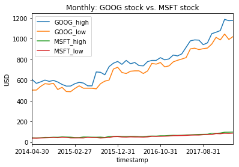

```python
plt.figure()
DailyMerged.plot()
plt.title("Daily: GOOG stock vs. MSFT stock ")
plt.ylabel("USD")
plt.xlabel("timestamp")

MonthlyMerged.plot()
plt.title("Monthly: GOOG stock vs. MSFT stock")
plt.ylabel("USD")
plt.xlabel("timestamp")

plt.show()
```

Firstly, I would look into the relationship between the high and the low value of a company in a short term and long term if there is any. Therefore, the scatter graph is used in order to find a trend between them.

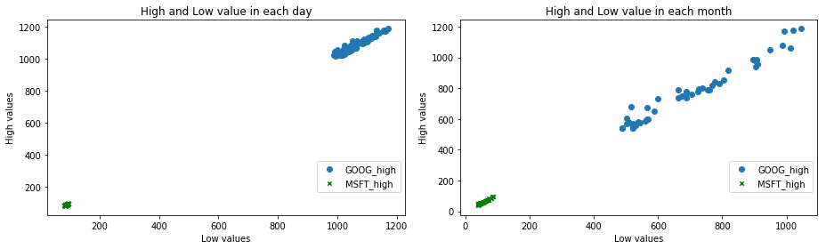

```python
fig = plt.figure(figsize=(13, 4))
plt.subplot(121) # to be compared easily, I use subplots
plt.scatter(DailyMerged["GOOG_low"],DailyMerged["GOOG_high"]) # between the high and the low of Google stocks
plt.scatter(DailyMerged["MSFT_low"],DailyMerged["MSFT_high"],c="green", s=20, marker="x") # between the high and the low of Microsoft stocks
plt.title("High and Low value in each day")
plt.ylabel("High values")
plt.xlabel("Low values")
plt.legend(loc='upper right', bbox_to_anchor=(1.0, 0.3))
#plt.show()
plt.subplot(122)
plt.scatter(MonthlyMerged["GOOG_low"],MonthlyMerged["GOOG_high"]) # same as before but monthly
plt.scatter(MonthlyMerged["MSFT_low"],MonthlyMerged["MSFT_high"],c="green", s=20, marker="x")
plt.title("High and Low value in each month")
plt.ylabel("High values")
plt.xlabel("Low values")
plt.legend(loc='upper right', bbox_to_anchor=(1.0, 0.3))
plt.tight_layout()
plt.show()
```

From the graphs, we can find a positive proportional trend between the high and the low values in both companies even if the distributions are not exactly on the same lines with a little bit of dispersion. In other words, we can expect increasing high values with increasing low values as well as decreasing high values with decreasing low values or vice versa.

There are individual graphs on the daily or the monthly basis. We have to watch out the scale as long as "sharey=False" because I would see patterns if they all look similar although the scales are different.

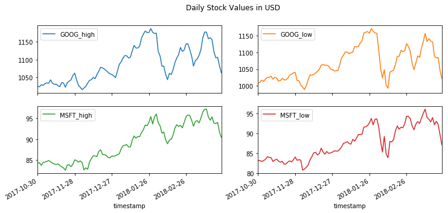

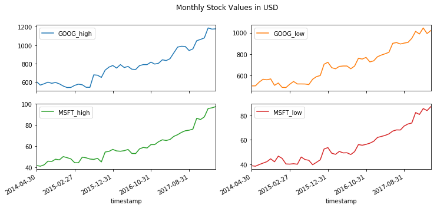

```python
fig = plt.figure()
DailyMerged.plot(kind='line', title="Daily Stock Values in USD",subplots=True, layout=(2,2), figsize=(12,5), sharey=False)
MonthlyMerged.plot(kind='line', title="Monthly Stock Values in USD",subplots=True, layout=(2,2), figsize=(12,5), sharey=False)
plt.show()
```

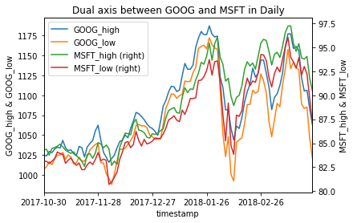

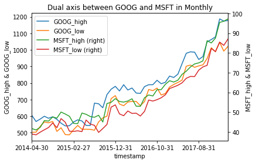

```python
plt.figure() # dual-axis graphs: to compare the trend regarding to their own scales
ax1 = DailyMerged.plot(secondary_y=['MSFT_low','MSFT_high'])
ax1.set_ylabel("GOOG_high & GOOG_low")
ax1.right_ax.set_ylabel("MSFT_high & MSFT_low")
plt.title("Dual axis between GOOG and MSFT in Daily")
plt.show()
ax2= MonthlyMerged.plot(secondary_y=['MSFT_low','MSFT_high'])
ax2.set_ylabel("GOOG_high & GOOG_low")
ax2.right_ax.set_ylabel("MSFT_high & MSFT_low")
plt.title("Dual axis between GOOG and MSFT in Monthly")
plt.show()
```

Interestingly, we could find the four lines having similar patterns during the same periods. It implies that Google and Microsoft stocks can be influenced by the same market situations or they can be a dependent variable for each other. We might also be allowed to predict the other's pattern with one side information.

This is a bar graph helps to understand the amount of values visusally.

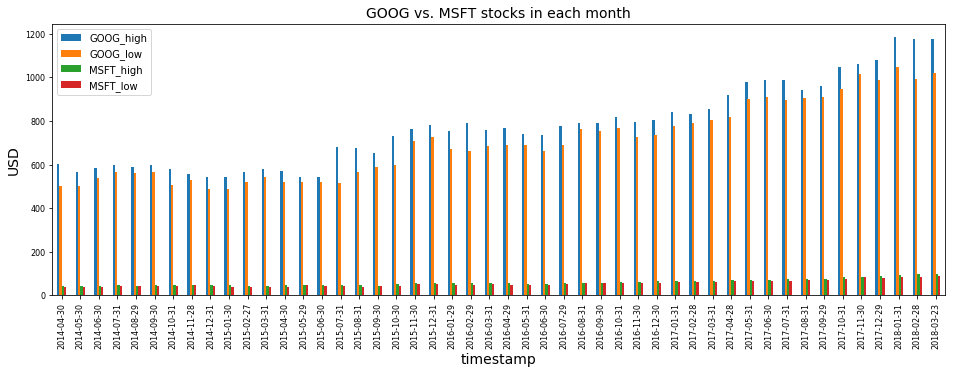

```python
p = MonthlyMerged.plot.bar(figsize=(16,5),fontsize=8) # bar graph helps to understand the amount of values visusally
p.set_xlabel("timestamp",fontsize=14)
p.set_ylabel("USD",fontsize=14)
p.set_title("GOOG vs. MSFT stocks in each month",fontsize=14)
plt.show()
```

This is a Stacked Histogram which shows the distribution of the data.

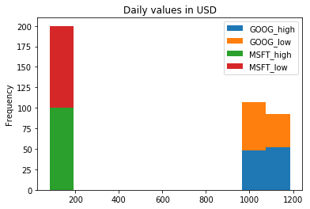

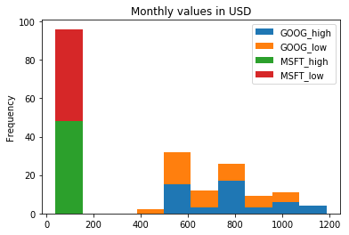

```python
DailyMerged.plot.hist(stacked=True) # Stacked Histogram which shows the distribution of the data.
plt.title("Daily values in USD")
MonthlyMerged.plot.hist(stacked=True)
plt.title("Monthly values in USD")
plt.show()
```

This is a histogram with bins of 12 for "MSFT_high" in MonthlyMerged.

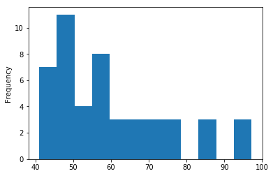

```python
MonthlyMerged["MSFT_high"].plot(kind="hist",bins=12) # histogram with 12 bins
plt.show()
```

The bins between 40 to 60 seem more often happened at the time on 24 March 2018.

This is a scatter matrix to visualise the relationship between all pairs of columns.

```
This is the relationship between daily stock series:
```

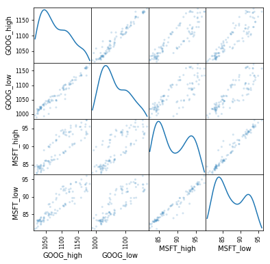

```
This is the relationship between monthly stock series:
```

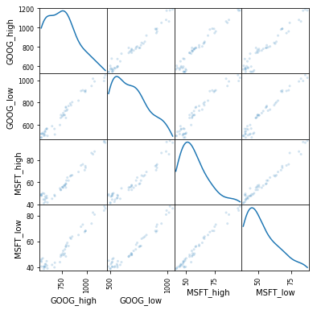

```python
from pandas.plotting import scatter_matrix

print("This is the relationship between daily stock series:")
scatter_matrix(DailyMerged, alpha=0.2, figsize=(6, 6), diagonal='kde')
plt.show()
print("This is the relationship between monthly stock series:")
scatter_matrix(MonthlyMerged, alpha=0.2, figsize=(6, 6), diagonal='kde')
plt.show()
```

From the scatter matrices, we could find three significant facts. Firstly, each company has similar patterns between the high and the low values. Secondly, both companies have more or less similar shapes of patterns. For example, peaks and valley. Lastly, the trends always fluctuate in any time scale but they can also show different shapes of patterns.

Now, I want to see the differences between the high values and the low values at the same time and the same company. Moreover, I also test the 1/12 times of Google stock difference with the one of Microsoft since I expect they are nearly the same except a certain degree of scales, which seems 12 times.

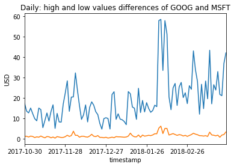

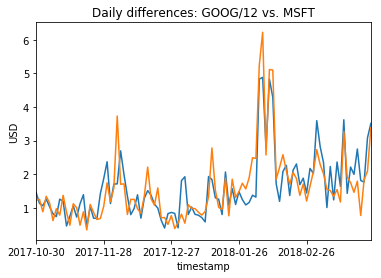

```python
plt.figure() # daily
dD_GOOG = DailyMerged["GOOG_high"] - DailyMerged["GOOG_low"] # difference between the high and the low at Google
dD_MSFT = DailyMerged["MSFT_high"] - DailyMerged["MSFT_low"] # difference between the high and the low at Microsoft
dD_GOOG.plot()
dD_MSFT.plot()
plt.title("Daily: high and low values differences of GOOG and MSFT")
plt.ylabel("USD")
plt.xlabel("timestamp")
plt.show()

dD_GOOG=dD_GOOG/12 # the difference by 1/12 times
dD_GOOG.plot()
dD_MSFT.plot() # compare them
plt.title("Daily differences: GOOG/12 vs. MSFT")
plt.ylabel("USD")
plt.xlabel("timestamp")
plt.show()
```

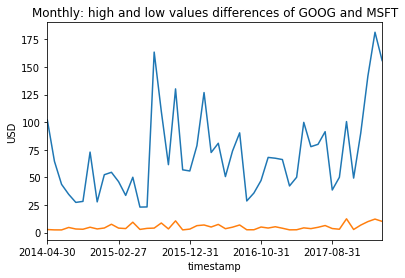

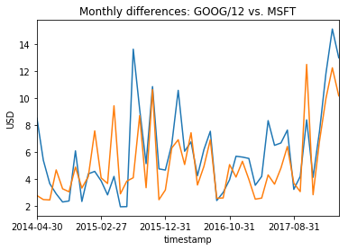

```python
plt.figure() # similar as before, but monthly
dD_GOOG = MonthlyMerged["GOOG_high"] - MonthlyMerged["GOOG_low"]
dD_MSFT = MonthlyMerged["MSFT_high"] - MonthlyMerged["MSFT_low"]
dD_GOOG.plot()
dD_MSFT.plot()
plt.title("Monthly: high and low values differences of GOOG and MSFT")
plt.ylabel("USD")
plt.xlabel("timestamp")
plt.show()

dD_GOOG=dD_GOOG/12
dD_GOOG.plot()
dD_MSFT.plot()
plt.title("Monthly differences: GOOG/12 vs. MSFT")
plt.ylabel("USD")
plt.xlabel("timestamp")
plt.show()
```

Surprisingly, the results of the difference are roughly same as expected. Therefore, I assume the gap between two companies could be expected by the difference of the mean between two companies which was nearly 12 times. (See the result of Descriptive Statistics)

## Tentative Conclusion

The daily and monthly based datasets are showing increasing patterns for Google and Microsoft as time goes by. The interesting thing is that both companies have very similar patterns as a positive proportional to each other. As we saw, the shorter term of the data seems more robust to predict in future. On the other hand, the longer term is dispersed around which implies higher variances so that the prediction can get a wider error range than the shorter one. For example, the daily basis dataset would be a good choice to predict if the stock will increase or decrease. However, as much of the time scale as the monthly basis data is, we would be allowed to predict further future with the monthly data instead of the daily data. As a result, I found Google and Microsoft stocks high potential to get even higher from the trends.

For the better prediction, I suggest getting more information about the past years. If possible, it will be also helpful with other IT companies stock information to understand the trend for the same industry. Lastly, the stocks of their joint corporations should be a good indicator as well.